# Anthony Botello

## 7.3

Looking at the plots below, we have identified the following features and ranges that we can use to further optimize our event selection:

| Feature | Lower Limit | Upper Limit |
| --- | --- | --- |
| $p_T$ | 450 | 495 |
| $\eta$ | -1.5 | 1.5 |
| $t_2$ | 0 | 0.5 |
| $t_3$ | 0 | 0.35 |
| $t_{21}$ | 0 | 0.5 |
| $k_t\Delta R$ | 0.4 | 1.0 |

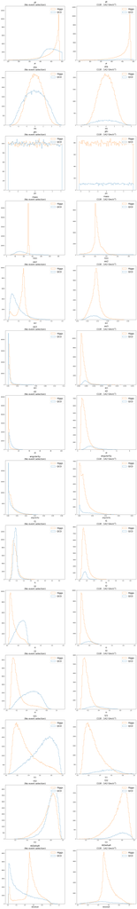

```python
fig,ax = plt.subplots(14,2,figsize=(20,140))

i = 0
for param in higgs:
    make_hist(i,param)
    i += 1
```

## 7.4

After selecting events based on the features and ranges given in 7.3, we found that selecting for $mass$, $p_T$, and $t_2$ had the greatest effect on improving the significance of our Higgs signal.

```python
feature_cuts = {'mass':[118,142],'pt':[450,495],'eta':[-1.5,1.5],'t2':[0,0.5],'t3':[0,0.35],'t21':[0,0.5],'KtDeltaR':[0.4,1.0]}

qcd_cut,higgs_cut = qcd.copy(),higgs.copy()
num_qcd,num_higgs = len(qcd_cut),len(higgs_cut)
es = expected_sigma(num_higgs,num_qcd)
print("|" + "Feature".ljust(15) + "|" + "Lower Limit".ljust(15) + "|" + "Upper Limit".ljust(15) + "|" + "Expected Sig.".ljust(15) + "|" + "Change in E.S.".ljust(15) + "|" + "Events (QCD, Higgs)".ljust(20) + "|")
print("-"*102)
print("|" + f"N/A".ljust(15) + "|" + f"N/A".ljust(15) + "|" + f"N/A".ljust(15) + "|" + f"{np.round(es,3)}".ljust(15) + "|" + f"N/A".ljust(15) + "|" + f"{(num_qcd,num_higgs)}".ljust(20) + "|")
print("-"*102)
for k,v in feature_cuts.items():
    qcd_cut,higgs_cut = make_cuts(v[0],v[1],k,qcd_cut,higgs_cut)
    num_qcd,num_higgs = len(qcd_cut),len(higgs_cut)
    delta_es = expected_sigma(len(higgs_cut),len(qcd_cut)) - es
    es = expected_sigma(len(higgs_cut),len(qcd_cut))
    print("|" + f"{k}".ljust(15) + "|" + f"{v[0]}".ljust(15) + "|" + f"{v[1]}".ljust(15) + "|" + f"{np.round(es,3)}".ljust(15) + "|" + f"{np.round(delta_es,3)}".ljust(15) + "|" + f"{(num_qcd,num_higgs)}".ljust(20) + "|")
    print("-"*102)
```

```
|Feature        |Lower Limit    |Upper Limit    |Expected Sig.  |Change in E.S. |Events (QCD, Higgs) |
------------------------------------------------------------------------------------------------------
|N/A            |N/A            |N/A            |0.707          |N/A            |(100000, 100000)    |
------------------------------------------------------------------------------------------------------
|mass           |118            |142            |1.733          |1.026          |(10538, 79573)      |
------------------------------------------------------------------------------------------------------
|pt             |450            |495            |2.384          |0.651          |(5088, 76052)       |
------------------------------------------------------------------------------------------------------
|eta            |-1.5           |1.5            |2.669          |0.285          |(4026, 75742)       |
------------------------------------------------------------------------------------------------------
|t2             |0              |0.5            |3.84           |1.171          |(1931, 75469)       |
------------------------------------------------------------------------------------------------------
|t3             |0              |0.35           |4.39           |0.55           |(1477, 75452)       |
------------------------------------------------------------------------------------------------------
|t21            |0              |0.5            |4.987          |0.597          |(1143, 75394)       |
------------------------------------------------------------------------------------------------------
|KtDeltaR       |0.4            |1.0            |5.426          |0.439          |(965, 75376)        |
------------------------------------------------------------------------------------------------------
```

After optimizing our event selection we were about to keep about 75% of our Higgs data, get rid of 99% of our QCD background data, and increase the expected significance from 0.707 to 5.426.

## 8.1

```python
len(high)
```

```
40344
```

```python
high_cut = high.copy()
for k,v in feature_cuts.items():
    high_cut = cut_data(v[0],v[1],k,high_cut)
```

```python
print(f'Observed significance: ', expected_sigma(len(higgs_cut),len(high_cut),L_qcd=len(high)))
```

```
Observed significance:  4.891474681402754
```

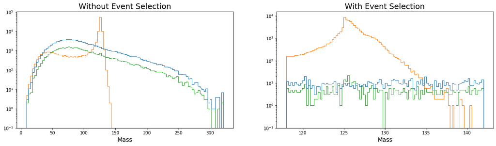

```python
fig,ax = plt.subplots(1,2,figsize=(20,5))
ax[0].hist([qcd.mass,higgs.mass,high.mass],bins=100,label=['QCD','Higgs','Observed'],histtype='step',log=True)
ax[0].set_title('Without Event Selection',fontsize=18)
ax[0].set_xlabel('Mass',fontsize=14)

ax[1].hist([qcd_cut.mass,higgs_cut.mass,high_cut.mass],bins=100,label=['QCD','Higgs','Observed'],histtype='step',log=True)
ax[1].set_title('With Event Selection',fontsize=18)
ax[1].set_xlabel('Mass',fontsize=14)
plt.show()
```

## 8.2

```python
low_cut = low.copy()
for k,v in feature_cuts.items():
    low_cut = cut_data(v[0],v[1],k,low_cut)
```

```python
print(f'Observed significance: ', expected_sigma(len(higgs_cut),len(low_cut),L_qcd=len(low)))
```

```
Observed significance:  5.007283606490258
```

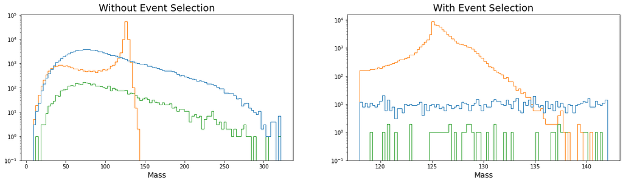

```python
fig,ax = plt.subplots(1,2,figsize=(20,5))
ax[0].hist([qcd.mass,higgs.mass,low.mass],bins=100,label=['QCD','Higgs','Observed'],histtype='step',log=True)
ax[0].set_title('Without Event Selection',fontsize=18)
ax[0].set_xlabel('Mass',fontsize=14)

ax[1].hist([qcd_cut.mass,higgs_cut.mass,low_cut.mass],bins=100,label=['QCD','Higgs','Observed'],histtype='step',log=True)
ax[1].set_title('With Event Selection',fontsize=18)
ax[1].set_xlabel('Mass',fontsize=14)
plt.show()
```